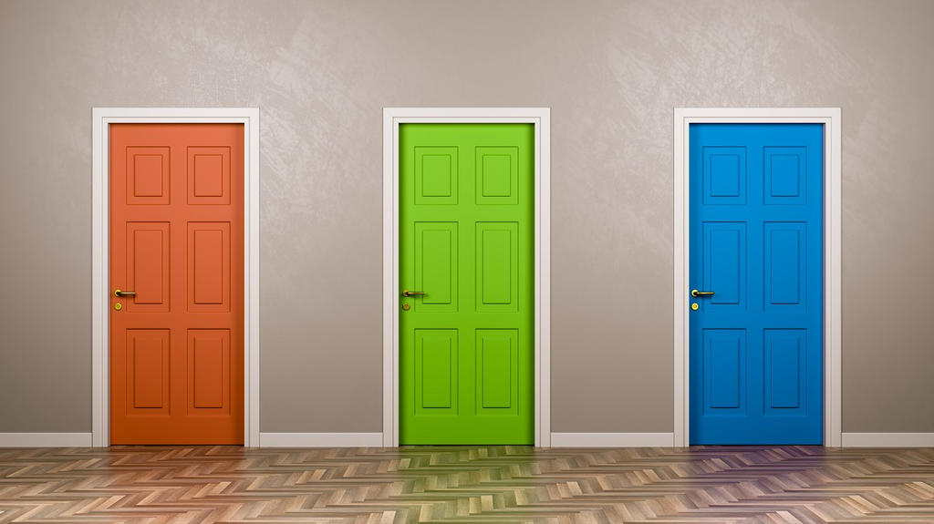

Monty Hall problem

The premise behind the Monty Hall problem is that you are presented with 3 doors: behind the two of the three doors are goats while behind of the remaining door is a car. At the start you will be given a choice to choose in one of the three doors, and after confirming your choice the host will open one of the unchosen doors.

At this point in time, you will have a 1 in 3 chance of selecting the door with the car behind it and 2 in 3 with a goat behind it.

After revealing one of the doors, which will always be a goat, you will be given a choice to change the door you chose or not. The big question is should you change doors or not. I believe that you should always switch.

### Answer

Lets say you will always choose door 1 and your strategy is to always switch at the second round

First Round

Scenario 1

```
Car/Goat/Goat
```

Scenario 2

```
Goat/Car/Goat
```

Scenario 3

```
Goat/Goat/Car
```

You are more likely to choose a goat in door 1.

```
  2/3 for goat
  1/3 for car
```

Second Round

In the scenario that you chose a car in the first place they will reveal either of the door with a goat in it and you will lose. But then again this is only gonna happen 1/3 of the time.

```
Car/**Goat**/Goat
Car/Goat/**Goat**
```

In the scenario that you chose a goat in the first place, which is more likely going to happen with 2/3 chances, they will be forced to show the goat. But because you know that they will do this in this scenario you know that the car will always be in the other door and you win.

```
Goat/Car/**Goat**
Goat/**Goat**/Car
```

The only time where you cannot say for certain what you will be choosing would be at the start It will be either the car or the goats. After they show you where one of the goat is the probability breaks down because either you win or lose with this strategy, with a 2/3 of the time you will win.

If you changed your strategy and will never switch then your probability of winning goes down to 1/3 because for you to win with this strategy you should be able to choose the car which is only in 1 of the 3 doors, which makes it 1/3.

[figure not shown]

PCSO Ultra Lotto 6/58

The PCSO Ultra Lotto 6/58 is played by choosing six numbers from 1-58. If one person were to buy all the tickets to ensure winning the ₱50 million jackpot, they would incur a massive loss since there are 29,142,257,760 possible combinations. Even if one ticket only costs ₱1, it would still leave the buyer at a major loss.

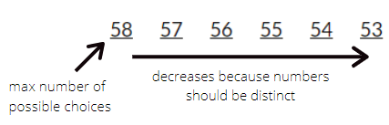

Figure 1